# Démographie

Curbcut

# 1 La démographie de Laval

Fondée en 1965 par la fusion de 14 anciennes municipalités, Laval s’étend sur 243 km² et couvre l’Île Jésus ainsi que les Îles Laval. Depuis sa création, la ville a connu une croissance démographique notable, passant d’une région rurale à un centre urbain dynamique. Laval est la troisième plus grande ville de la province en termes d’habitant·e·s, après Montréal et Québec.

En 2025, la population de Laval est estimée à 460 000[^1], avec une densité moyenne de 1 890 personnes par kilomètre carré. Comme le montre la carte du graphique 1.1, les secteurs les plus densément peuplés se retrouvent à Chomedey et Laval-des-Rapides, Pont-Viau.

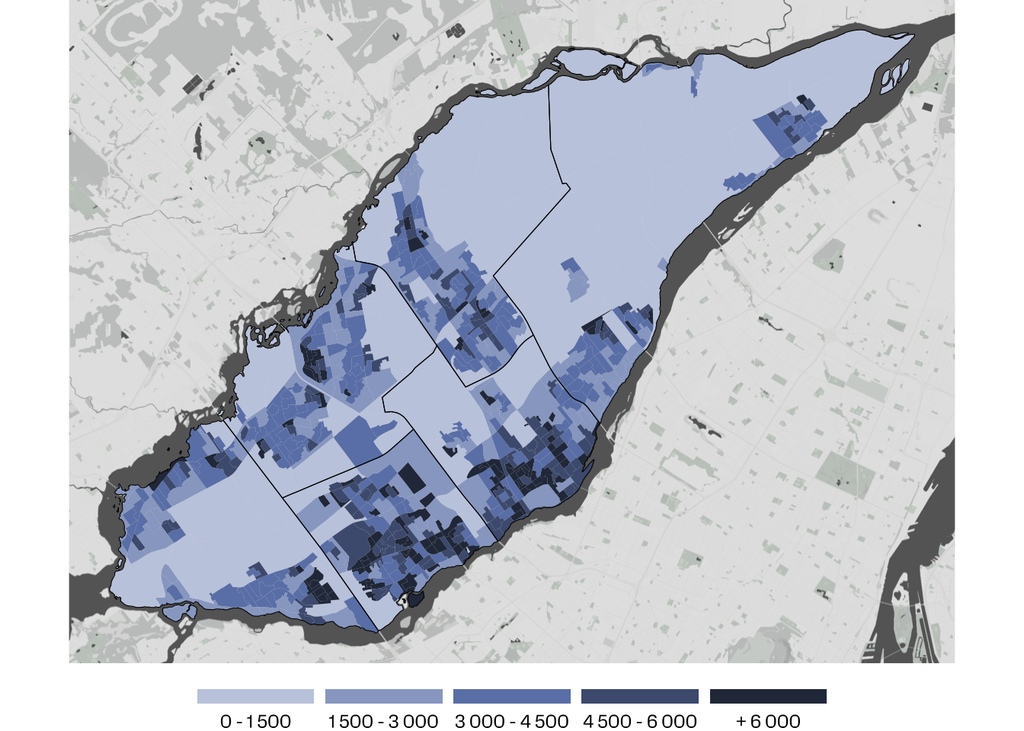

Figure 1.1: Densité de la population lavalloise par km² (2021)

## 1.1 Structure de la population

En 2025, l’âge moyen des Lavallois·es est de 42.6[^2], comparativement à 42.8 ans pour l’ensemble de la province. Les jeunes de moins de 18 ans constituent 19,3 % de la population de Laval, une proportion un peu plus élevée que celle du Québec dans son ensemble, qui est de 18,6 %. En 2025, le nombre de personnes âgées de 65 ans surpassent celui des jeunes. Elles représentent 20,0 % de la population lavalloise, ce qui était légèrement inférieur à la proportion de l’ensemble de la province (21,7 %). Comparativement à l’ensemble du Québec, la distribution de la population de Laval comporte une plus faible proportion de jeunes adultes (18-44 ans), mais une plus grande proportion d’adultes (45-64 ans), comme le montre le graphique 1.2 ci-dessous.

La répartition par genre à Laval est de 49,4 % pour les hommes et de 50,6 % pour les femmes en 2025.

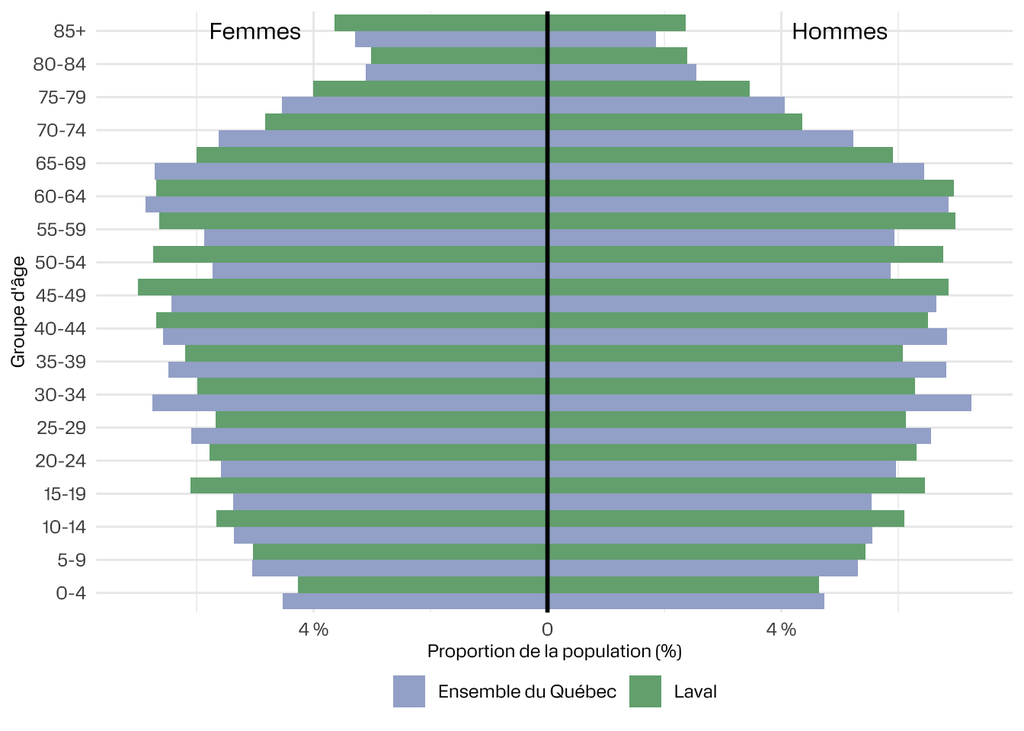

Figure 1.2: Répartition de la population par âge et par sexe, Laval et Ensemble du Québec (2021)

En 2021, plus du tiers de la population lavalloise (37,0 %) a déclaré être d’origine ethnique ou culturelle européenne, suivi par 28,6 % d’origine nord-américaine, 18,3 % asiatique, 10,7 % africaine, 10,6 % caribéenne ou d’Amérique centrale et du Sud, et 7,2 % d’origine océanique ou d’autres réponses.

Définition: Origine ethnique - *L’origine ethnique d’une personne fait référence aux origines ethniques ou culturelles de ses ancêtres. Un ancêtre est souvent plus éloigné qu’un grand-parent.* - *Une personne peut déclarer plus d’une origine ethnique ou culturelle.*[^3]

## 1.2 Croissance de la population

[output not shown]